# 1. INTRODUCTION

# 8. Modeling

### Since the problem here is a binary classification problem therefore, following are the algorithms that will be considered for the further data analysis and prediction :

1. Logistic Regression
2. Decision Tree
3. Radom Forest
4. Principal Component Analysis (PCA)

8.1 Replacing 0’s or NaN's with the median of the respective attribute :-

```python
df = df.fillna(df.median())
df['Outcome'] = df['Outcome'].astype(int)
df.describe().T
```

|  | count | mean | std | min | 25% | 50% | 75% | max |
| --- | --- | --- | --- | --- | --- | --- | --- | --- |
| Pregnancies | 768.0 | 3.845052 | 3.369578 | 0.000 | 1.00000 | 3.0000 | 6.00000 | 17.00 |
| Glucose | 768.0 | 121.656250 | 30.438286 | 44.000 | 99.75000 | 117.0000 | 140.25000 | 199.00 |
| BloodPressure | 768.0 | 72.386719 | 12.096642 | 24.000 | 64.00000 | 72.0000 | 80.00000 | 122.00 |
| SkinThickness | 768.0 | 29.108073 | 8.791221 | 7.000 | 25.00000 | 29.0000 | 32.00000 | 99.00 |
| Insulin | 768.0 | 140.671875 | 86.383060 | 14.000 | 121.50000 | 125.0000 | 127.25000 | 846.00 |
| BMI | 768.0 | 32.455208 | 6.875177 | 18.200 | 27.50000 | 32.3000 | 36.60000 | 67.10 |
| DiabetesPedigreeFunction | 768.0 | 0.471876 | 0.331329 | 0.078 | 0.24375 | 0.3725 | 0.62625 | 2.42 |
| Age | 768.0 | 33.240885 | 11.760232 | 21.000 | 24.00000 | 29.0000 | 41.00000 | 81.00 |
| Outcome | 768.0 | 0.348958 | 0.476951 | 0.000 | 0.00000 | 0.0000 | 1.00000 | 1.00 |

8.2 Scaling of the Data :-

- Min-max normalization is a normalization strategy which linearly transforms x to y = (x-min)/(max-min), where min and max are the minimum and maximum values in X, where X is the set of observed values of x.
- It can be easily seen that when x=min, then y=0, and When x=max, then y=1.

```python
scaler = MinMaxScaler()
# fit and transform the data using the scaler
df = pd.DataFrame(scaler.fit_transform(df), columns=df.columns)
# print the normalized data
df.head()
```

|  | Pregnancies | Glucose | BloodPressure | SkinThickness | Insulin | BMI | DiabetesPedigreeFunction | Age | Outcome |
| --- | --- | --- | --- | --- | --- | --- | --- | --- | --- |
| 0 | 0.352941 | 0.670968 | 0.489796 | 0.304348 | 0.133413 | 0.314928 | 0.234415 | 0.483333 | 1.0 |
| 1 | 0.058824 | 0.264516 | 0.428571 | 0.239130 | 0.133413 | 0.171779 | 0.116567 | 0.166667 | 0.0 |
| 2 | 0.470588 | 0.896774 | 0.408163 | 0.239130 | 0.133413 | 0.104294 | 0.253629 | 0.183333 | 1.0 |
| 3 | 0.058824 | 0.290323 | 0.428571 | 0.173913 | 0.096154 | 0.202454 | 0.038002 | 0.000000 | 0.0 |
| 4 | 0.000000 | 0.600000 | 0.163265 | 0.304348 | 0.185096 | 0.509202 | 0.943638 | 0.200000 | 1.0 |

8.3 Splitting the dataset into 2 parts :-

1. Training Dataset - The sample of data used to fit the model. The model sees and learns from this data.
2. Test Dataset - The sample of data used to provide an unbiased evaluation of a final model fit on the training dataset.

```python
column_sels = ['Pregnancies', 'Glucose', 'BloodPressure', 'SkinThickness', 'Insulin', 'BMI', 'DiabetesPedigreeFunction', 'Age']
X = df.loc[:,column_sels]
y = df['Outcome'].astype(int)
```

8.4 Class Balancing :-

- A balanced data set is a set that contains all elements observed in all time frame.
- Whereas unbalanced data is a set of data where certain years, the data category is not observed. Imbalanced data typically refers to a problem with classification problems where the classes are not represented equally.
- Imbalanced data set will lead algorithms to get good results by returning the majority. That will be a problem if you are interested in the minority more. So, balancing is a way to force the algorithm to give more weight to the minority i.e., many classification learning algorithms have low predictive accuracy for the infrequent class.
- Oversampling and undersampling in data analysis are techniques used to adjust the class distribution of a data set

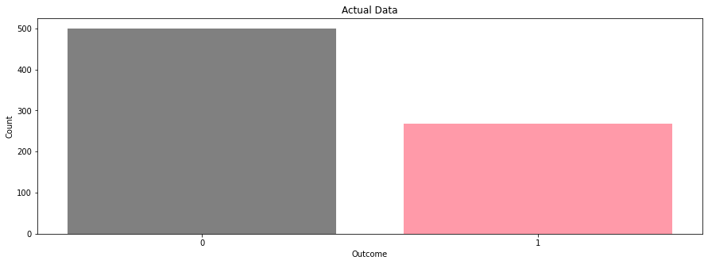

```python
y2 = y.astype(str)
colors = {0:'#808080', 1:'#ff9aa9'}
plt.figure(figsize=(15,5))
plt.bar(list(y2.value_counts().index), y2.value_counts(),  color=['#808080','#ff9aa9'])
plt.title('Actual Data')
plt.xlabel('Outcome')
plt.ylabel('Count')
plt.show();
```

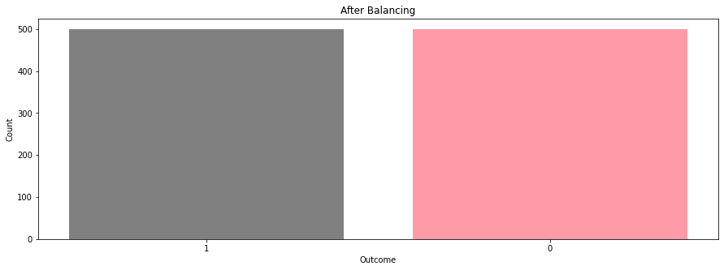

```python
oversample = SMOTE()
X, y = oversample.fit_resample(X, y)
y2 = y.astype(str)
colors = {0:'#808080', 1:'#ff9aa9'}
plt.figure(figsize=(15,5))
plt.bar(list(y2.value_counts().index), y2.value_counts(),  color=['#808080','#ff9aa9'])
plt.title('After Balancing')
plt.xlabel('Outcome')
plt.ylabel('Count')
plt.show();
```

```python
# using the train test split function
X_train, X_test, y_train, y_test = train_test_split(X,y,random_state=104,test_size=0.20,shuffle=True)
```